# Are there significant differences in independent variables between high-risk and low-risk groups for heart disease?

2025-09-28

# Data Loading

```r
Heart_data <- data.frame(read.csv("heart_attack_prediction_dataset_01.csv"))
str(Heart_data)
```

```
## 'data.frame':    441456 obs. of  12 variables:
##  $ Patient_ID               : num  2.02e+09 2.02e+09 2.02e+09 2.02e+09 2.02e+09 ...
##  $ Age_Group_5yr            : num  9 7 11 9 9 11 11 13 13 10 ...
##  $ Sex                      : num  2 2 2 2 2 2 2 1 2 1 ...
##  $ High_Blood_Pressure      : num  1 3 3 1 3 1 1 1 3 1 ...
##  $ Diabetes_Status          : num  3 3 3 3 3 3 3 3 3 3 ...
##  $ Smoking_Status           : num  1 2 9 1 1 1 1 1 1 1 ...
##  $ X_BMI5                   : num  4018 2509 2204 2819 2437 ...
##  $ Heavy_Drinking_Risk      : num  1 1 9 1 1 1 1 1 1 1 ...
##  $ Fruit_Recommendations_Met: num  2 2 9 1 9 1 1 1 9 1 ...
##  $ CVD_Stroke_History       : num  2 2 1 2 2 2 2 2 2 2 ...
##  $ Heart_Attack_History     : num  2 2 7 2 2 2 2 7 2 2 ...
##  $ Coronary_Heart_Disease   : num  2 2 2 2 2 2 2 2 2 2 ...
```

```r
summary(Heart_data)
```

```
##    Patient_ID       Age_Group_5yr       Sex       High_Blood_Pressure
##  Min.   :2.02e+09   Min.   : 1.0   Min.   :1.00   Min.   :1.00
##  1st Qu.:2.02e+09   1st Qu.: 5.0   1st Qu.:1.00   1st Qu.:1.00
##  Median :2.02e+09   Median : 8.0   Median :2.00   Median :3.00
##  Mean   :2.02e+09   Mean   : 7.8   Mean   :1.58   Mean   :2.21
##  3rd Qu.:2.02e+09   3rd Qu.:10.0   3rd Qu.:2.00   3rd Qu.:3.00
##  Max.   :2.02e+09   Max.   :14.0   Max.   :2.00   Max.   :9.00
##                                                   NA's   :1
##  Diabetes_Status Smoking_Status     X_BMI5      Heavy_Drinking_Risk
##  Min.   :1.00    Min.   :1.00   Min.   :1202    Min.   :1.00
##  1st Qu.:3.00    1st Qu.:1.00   1st Qu.:2373    1st Qu.:1.00
##  Median :3.00    Median :1.00   Median :2695    Median :1.00
##  Mean   :2.76    Mean   :1.47   Mean   :2804    Mean   :1.52
##  3rd Qu.:3.00    3rd Qu.:1.00   3rd Qu.:3090    3rd Qu.:1.00
##  Max.   :9.00    Max.   :9.00   Max.   :9995    Max.   :9.00
##  NA's   :7                      NA's   :36398
##  Fruit_Recommendations_Met CVD_Stroke_History Heart_Attack_History
##  Min.   :1.00              Min.   :1.00       Min.   :1.00
##  1st Qu.:1.00              1st Qu.:2.00       1st Qu.:2.00
##  Median :1.00              Median :2.00       Median :2.00
##  Mean   :2.13              Mean   :1.97       Mean   :1.97
##  3rd Qu.:2.00              3rd Qu.:2.00       3rd Qu.:2.00
##  Max.   :9.00              Max.   :9.00       Max.   :9.00
##
##  Coronary_Heart_Disease
##  Min.   :1.00
##  1st Qu.:2.00
##  Median :2.00
##  Mean   :1.92
##  3rd Qu.:2.00
##  Max.   :9.00
##  NA's   :1
```

# Confirm missing value ratio

```r
cat("=== MISSING VALUE ANALYSIS FOR STATISTICAL DECISION MAKING ===\n")
```

```
## === MISSING VALUE ANALYSIS FOR STATISTICAL DECISION MAKING ===
```

```r
# Check missing percentages for all variables to make informed decisions
missing_analysis <- data.frame(
  Variable = names(Heart_data),
  Missing_Count = sapply(Heart_data, function(x) sum(is.na(x))),
  Missing_Percent = sapply(Heart_data, function(x) round((sum(is.na(x)) / length(x)) * 100, 2))
)

# Sort by missing percentage
missing_analysis <- missing_analysis[order(-missing_analysis$Missing_Percent), ]
print(missing_analysis)
```

```
##                                            Variable Missing_Count
## X_BMI5                                       X_BMI5         36398
## Patient_ID                               Patient_ID             0
## Age_Group_5yr                         Age_Group_5yr             0
## Sex                                             Sex             0
## High_Blood_Pressure             High_Blood_Pressure             1
## Diabetes_Status                     Diabetes_Status             7
## Smoking_Status                       Smoking_Status             0
## Heavy_Drinking_Risk             Heavy_Drinking_Risk             0
## Fruit_Recommendations_Met Fruit_Recommendations_Met             0
## CVD_Stroke_History               CVD_Stroke_History             0
## Heart_Attack_History           Heart_Attack_History             0
## Coronary_Heart_Disease       Coronary_Heart_Disease             1
##                           Missing_Percent
## X_BMI5                               8.24
## Patient_ID                           0.00
## Age_Group_5yr                        0.00
## Sex                                  0.00
## High_Blood_Pressure                  0.00
## Diabetes_Status                      0.00
## Smoking_Status                       0.00
## Heavy_Drinking_Risk                  0.00
## Fruit_Recommendations_Met            0.00
## CVD_Stroke_History                   0.00
## Heart_Attack_History                 0.00
## Coronary_Heart_Disease               0.00
```

```r
# Focus on the four continuous variables
continuous_vars <- c("X_BMI5", "Physical_Activity_Minutes", "Mental_Health_Days", "Poor_Physical_Health_Days")

cat("\n=== CONTINUOUS VARIABLES MISSING VALUE RATES ===\n")
```

```
##
## === CONTINUOUS VARIABLES MISSING VALUE RATES ===
```

```r
for(var in continuous_vars) {
  if(var %in% names(Heart_data)) {
    missing_count <- sum(is.na(Heart_data[[var]]))
    missing_pct <- (missing_count / nrow(Heart_data)) * 100
    cat(sprintf("• %s: %d missing (%.1f%%)\n", var, missing_count, missing_pct))
  }
}
```

```
## • X_BMI5: 36398 missing (8.2%)
```

```r
# Categorize variables by missing percentage for appropriate handling
high_missing <- missing_analysis$Variable[missing_analysis$Missing_Percent > 50]
moderate_missing <- missing_analysis$Variable[missing_analysis$Missing_Percent >= 5 & missing_analysis$Missing_Percent <= 50]
low_missing <- missing_analysis$Variable[missing_analysis$Missing_Percent < 5]

cat("\nVariables categorized by missing percentage:\n")
```

```
##
## Variables categorized by missing percentage:
```

```r
cat("HIGH (>50% missing - should DROP):", paste(high_missing, collapse = ", "), "\n")
```

```
## HIGH (>50% missing - should DROP):
```

```r
cat("MODERATE (5-50% missing - consider imputation):", paste(moderate_missing, collapse = ", "), "\n")
```

```
## MODERATE (5-50% missing - consider imputation): X_BMI5
```

```r
cat("LOW (<5% missing - complete case analysis):", paste(low_missing, collapse = ", "), "\n")
```

```
## LOW (<5% missing - complete case analysis): Patient_ID, Age_Group_5yr, Sex, High_Blood_Pressure, Diabetes_Status, Smoking_Status, Heavy_Drinking_Risk, Fruit_Recommendations_Met, CVD_Stroke_History, Heart_Attack_History, Coronary_Heart_Disease
```

# Data Transformation

```r
Heart_data$Age_Group_5yr <- factor(
  Heart_data$Age_Group_5yr,
  levels = 1:13,
  labels = c(
    "18-24", "25-29", "30-34", "35-39", "40-44",
    "45-49", "50-54", "55-59", "60-64", "65-69",
    "70-74", "75-79", "80+")
)
Heart_data$Sex <- factor(
  Heart_data$Sex,
  levels = c(1, 2),
  labels = c("Male", "Female")
)
Heart_data$High_Blood_Pressure <- factor(
  Heart_data$High_Blood_Pressure,
  levels = c(1, 2, 3, 4),
  labels = c("Yes", "Yes/borderline high", "Yes/pregnancy only", "No")
)
Heart_data$Diabetes_Status <- factor(
  Heart_data$Diabetes_Status,
  levels = c(1, 2, 3, 4),
  labels = c("Yes", "Yes/borderline", "Yes/pregnancy only", "No")
)
Heart_data$Smoking_Status <- factor(
  Heart_data$Smoking_Status,
  levels = c(1, 2),
  labels = c("Yes", "No")
)
Heart_data$Heavy_Drinking_Risk <- factor(
  Heart_data$Heavy_Drinking_Risk,
  levels = c(1, 2),
  labels = c("Yes", "No")
)
Heart_data$Fruit_Recommendations_Met <- factor(
  Heart_data$Fruit_Recommendations_Met,
  levels = c(1, 2),
  labels = c("Yes", "No")
)
Heart_data$CVD_Stroke_History <- factor(
  Heart_data$CVD_Stroke_History,
  levels = c(1, 2),
  labels = c("Yes", "No")
)
Heart_data$Coronary_Heart_Disease <- factor(
  Heart_data$Coronary_Heart_Disease,
  levels = c(1, 2),
  labels = c("Yes", "No")
)
Heart_data$Heart_Attack_History <- factor(
  Heart_data$Heart_Attack_History,
  levels = c(1, 2),
  labels = c("Yes", "No")
)

Heart_data$X_BMI5 <- Heart_data$X_BMI5 / 100
# DO NOT IMPUTE HERE - We'll handle missing values properly in the cleaning section
# Heart_data$X_BMI5[is.na(Heart_data$X_BMI5)] <- mean(Heart_data$X_BMI5, na.rm = TRUE)  # WRONG APPROACH

str(Heart_data)
```

```
## 'data.frame':    441456 obs. of  12 variables:
##  $ Patient_ID               : num  2.02e+09 2.02e+09 2.02e+09 2.02e+09 2.02e+09 ...
##  $ Age_Group_5yr            : Factor w/ 13 levels "18-24","25-29",..: 9 7 11 9 9 11 11 13 13 10 ...
##  $ Sex                      : Factor w/ 2 levels "Male","Female": 2 2 2 2 2 2 2 1 2 1 ...
##  $ High_Blood_Pressure      : Factor w/ 4 levels "Yes","Yes/borderline high",..: 1 3 3 1 3 1 1 1 3 1 ...
##  $ Diabetes_Status          : Factor w/ 4 levels "Yes","Yes/borderline",..: 3 3 3 3 3 3 3 3 3 3 ...
##  $ Smoking_Status           : Factor w/ 2 levels "Yes","No": 1 2 NA 1 1 1 1 1 1 1 ...
##  $ X_BMI5                   : num  40.2 25.1 22 28.2 24.4 ...
##  $ Heavy_Drinking_Risk      : Factor w/ 2 levels "Yes","No": 1 1 NA 1 1 1 1 1 1 1 ...
##  $ Fruit_Recommendations_Met: Factor w/ 2 levels "Yes","No": 2 2 NA 1 NA 1 1 1 NA 1 ...
##  $ CVD_Stroke_History       : Factor w/ 2 levels "Yes","No": 2 2 1 2 2 2 2 2 2 2 ...
##  $ Heart_Attack_History     : Factor w/ 2 levels "Yes","No": 2 2 NA 2 2 2 2 NA 2 2 ...
##  $ Coronary_Heart_Disease   : Factor w/ 2 levels "Yes","No": 2 2 2 2 2 2 2 2 2 2 ...
```

```r
summary(Heart_data)
```

```
##    Patient_ID       Age_Group_5yr        Sex
##  Min.   :2.02e+09   60-64  : 49794   Male  :186938
##  1st Qu.:2.02e+09   65-69  : 49264   Female:254518
##  Median :2.02e+09   55-59  : 46209
##  Mean   :2.02e+09   50-54  : 39881
##  3rd Qu.:2.02e+09   70-74  : 38362
##  Max.   :2.02e+09   (Other):212610
##                     NA's   :  5336
##           High_Blood_Pressure           Diabetes_Status   Smoking_Status
##  Yes                :178188   Yes               : 57256   Yes :361885
##  Yes/borderline high:  3271   Yes/borderline    :  3608   No  : 61581
##  Yes/pregnancy only :254318   Yes/pregnancy only:372104   NA's: 17990
##  No                 :  4312   No                :  7690
##  NA's               :  1367   NA's              :   798
##
##
##      X_BMI5      Heavy_Drinking_Risk Fruit_Recommendations_Met
##  Min.   : 12.0   Yes :393658         Yes :247817
##  1st Qu.: 23.7   No  : 22065         No  :149928
##  Median : 26.9   NA's: 25733         NA's: 43711
##  Mean   : 28.0
##  3rd Qu.: 30.9
##  Max.   :100.0
##  NA's   :36398
##  CVD_Stroke_History Heart_Attack_History Coronary_Heart_Disease
##  Yes : 18269        Yes : 25472          Yes : 41776
##  No  :421897        No  :413755          No  :398420
##  NA's:  1290        NA's:  2229          NA's:  1260
##
##
##
##
```

# Data Cleaning

## Statistically Sound Missing Value Handling

```r
cat("=== APPLYING EVIDENCE-BASED MISSING VALUE TREATMENT ===\n")
```

```
## === APPLYING EVIDENCE-BASED MISSING VALUE TREATMENT ===
```

```r
# Step 1: Drop variables with >50% missing (statistically unreliable)
Heart_clean <- Heart_data

# Check which variables have >50% missing and should be dropped
high_missing_vars <- c()
for(var in names(Heart_clean)) {
  missing_pct <- (sum(is.na(Heart_clean[[var]])) / nrow(Heart_clean)) * 100
  if(missing_pct > 50) {
    high_missing_vars <- c(high_missing_vars, var)
  }
}

if(length(high_missing_vars) > 0) {
  cat("Dropping variables with >50% missing:", paste(high_missing_vars, collapse = ", "), "\n")
  Heart_clean <- Heart_clean[, !names(Heart_clean) %in% high_missing_vars]
}

# Step 2: Handle continuous variables with 5-20% missing (ONLY these get imputed)
continuous_vars <- c("X_BMI5", "Physical_Activity_Minutes", "Mental_Health_Days", "Poor_Physical_Health_Days")
available_continuous <- continuous_vars[continuous_vars %in% names(Heart_clean)]

cat("\n=== CONTINUOUS VARIABLE IMPUTATION (5-20% missing only) ===\n")
```

```
##
## === CONTINUOUS VARIABLE IMPUTATION (5-20% missing only) ===
```

```r
for(var in available_continuous) {
  missing_count <- sum(is.na(Heart_clean[[var]]))
  missing_pct <- (missing_count / nrow(Heart_clean)) * 100

  if(missing_pct >= 5 && missing_pct <= 20) {
    # Use MEDIAN imputation (more robust than mean)
    var_median <- median(Heart_clean[[var]], na.rm = TRUE)
    Heart_clean[[var]][is.na(Heart_clean[[var]])] <- var_median
    cat(sprintf("✅ %s: Imputed %d values (%.1f%%) with MEDIAN (%.2f)\n",
                var, missing_count, missing_pct, var_median))
  } else if(missing_pct > 20) {
    cat(sprintf("⚠️  %s: %.1f%% missing - Consider advanced imputation or dropping\n", var, missing_pct))
  } else {
    cat(sprintf("• %s: %.1f%% missing - Keeping as NA for complete case analysis\n", var, missing_pct))
  }
}
```

```
## ✅ X_BMI5: Imputed 36398 values (8.2%) with MEDIAN (26.95)
```

```r
# Step 3: For categorical variables - NO imputation, use complete case analysis
cat("\n=== CATEGORICAL VARIABLES - NO IMPUTATION ===\n")
```

```
##
## === CATEGORICAL VARIABLES - NO IMPUTATION ===
```

```r
categorical_vars <- names(Heart_clean)[sapply(Heart_clean, function(x) is.factor(x) || is.character(x))]
for(var in categorical_vars) {
  missing_count <- sum(is.na(Heart_clean[[var]]))
  missing_pct <- (missing_count / nrow(Heart_clean)) * 100
  if(missing_count > 0) {
    cat(sprintf("• %s: %d missing (%.1f%%) - Will use complete case analysis\n", var, missing_count, missing_pct))
  }
}
```

```
## • Age_Group_5yr: 5336 missing (1.2%) - Will use complete case analysis
## • High_Blood_Pressure: 1367 missing (0.3%) - Will use complete case analysis
## • Diabetes_Status: 798 missing (0.2%) - Will use complete case analysis
## • Smoking_Status: 17990 missing (4.1%) - Will use complete case analysis
## • Heavy_Drinking_Risk: 25733 missing (5.8%) - Will use complete case analysis
## • Fruit_Recommendations_Met: 43711 missing (9.9%) - Will use complete case analysis
## • CVD_Stroke_History: 1290 missing (0.3%) - Will use complete case analysis
## • Heart_Attack_History: 2229 missing (0.5%) - Will use complete case analysis
## • Coronary_Heart_Disease: 1260 missing (0.3%) - Will use complete case analysis
```

```r
# Step 4: Remove rows with missing CRITICAL variables only
critical_vars <- c("Heart_Attack_History", "Age_Group_5yr", "Sex")
available_critical <- critical_vars[critical_vars %in% names(Heart_clean)]

rows_before <- nrow(Heart_clean)
Heart_clean <- Heart_clean[complete.cases(Heart_clean[available_critical]), ]
rows_after <- nrow(Heart_clean)

cat(sprintf("\n=== FINAL RESULTS ===\n"))
```

```
##
## === FINAL RESULTS ===
```

```r
cat(sprintf("Rows removed due to missing CRITICAL variables: %d\n", rows_before - rows_after))
```

```
## Rows removed due to missing CRITICAL variables: 7457
```

```r
cat(sprintf("Final dataset: %d rows × %d columns\n", nrow(Heart_clean), ncol(Heart_clean)))
```

```
## Final dataset: 433999 rows × 12 columns
```

```r
cat(sprintf("Data retention rate: %.1f%%\n", (rows_after / nrow(Heart_data)) * 100))
```

```
## Data retention rate: 98.3%
```

```r
# Check remaining missing values
remaining_missing <- sapply(Heart_clean, function(x) sum(is.na(x)))
remaining_missing <- remaining_missing[remaining_missing > 0]
if(length(remaining_missing) > 0) {
  cat("\nRemaining missing values (for complete case analysis in specific tests):\n")
  print(remaining_missing)
} else {
  cat("\n✅ No remaining missing values\n")
}
```

```
##
## Remaining missing values (for complete case analysis in specific tests):
##       High_Blood_Pressure           Diabetes_Status            Smoking_Status
##                      1109                       615                     16989
##       Heavy_Drinking_Risk Fruit_Recommendations_Met        CVD_Stroke_History
##                     24409                     41839                      1006
##    Coronary_Heart_Disease
##                      1086
```

```r
str(Heart_clean)
```

```
## 'data.frame':    433999 obs. of  12 variables:
##  $ Patient_ID               : num  2.02e+09 2.02e+09 2.02e+09 2.02e+09 2.02e+09 ...
##  $ Age_Group_5yr            : Factor w/ 13 levels "18-24","25-29",..: 9 7 9 9 11 11 13 10 9 13 ...
##  $ Sex                      : Factor w/ 2 levels "Male","Female": 2 2 2 2 2 2 2 1 2 2 ...
##  $ High_Blood_Pressure      : Factor w/ 4 levels "Yes","Yes/borderline high",..: 1 3 1 3 1 1 3 1 1 1 ...
##  $ Diabetes_Status          : Factor w/ 4 levels "Yes","Yes/borderline",..: 3 3 3 3 3 3 3 3 3 1 ...
##  $ Smoking_Status           : Factor w/ 2 levels "Yes","No": 1 2 1 1 1 1 1 1 1 1 ...
##  $ X_BMI5                   : num  40.2 25.1 28.2 24.4 26.5 ...
##  $ Heavy_Drinking_Risk      : Factor w/ 2 levels "Yes","No": 1 1 1 1 1 1 1 1 1 1 ...
##  $ Fruit_Recommendations_Met: Factor w/ 2 levels "Yes","No": 2 2 1 NA 1 1 NA 1 2 2 ...
##  $ CVD_Stroke_History       : Factor w/ 2 levels "Yes","No": 2 2 2 2 2 2 2 2 2 1 ...
##  $ Heart_Attack_History     : Factor w/ 2 levels "Yes","No": 2 2 2 2 2 2 2 2 2 2 ...
##  $ Coronary_Heart_Disease   : Factor w/ 2 levels "Yes","No": 2 2 2 2 2 2 2 2 2 1 ...
```

```r
summary(Heart_clean)
```

```
##    Patient_ID       Age_Group_5yr        Sex
##  Min.   :2.02e+09   60-64  : 49562   Male  :183997
##  1st Qu.:2.02e+09   65-69  : 49056   Female:250002
##  Median :2.02e+09   55-59  : 46005
##  Mean   :2.02e+09   50-54  : 39735
##  3rd Qu.:2.02e+09   70-74  : 38120
##  Max.   :2.02e+09   80+    : 36344
##                     (Other):175177
##           High_Blood_Pressure           Diabetes_Status   Smoking_Status
##  Yes                :175049   Yes               : 56197   Yes :356110
##  Yes/borderline high:  3242   Yes/borderline    :  3553   No  : 60900
##  Yes/pregnancy only :250345   Yes/pregnancy only:366078   NA's: 16989
##  No                 :  4254   No                :  7556
##  NA's               :  1109   NA's              :   615
##
##
##      X_BMI5      Heavy_Drinking_Risk Fruit_Recommendations_Met
##  Min.   : 12.0   Yes :387699         Yes :244243
##  1st Qu.: 24.0   No  : 21891         No  :147917
##  Median : 26.9   NA's: 24409         NA's: 41839
##  Mean   : 28.0
##  3rd Qu.: 30.5
##  Max.   :100.0
##
##  CVD_Stroke_History Heart_Attack_History Coronary_Heart_Disease
##  Yes : 17832        Yes: 25284           Yes : 41102
##  No  :415161        No :408715           No  :391811
##  NA's:  1006                             NA's:  1086
##
##
##
##
```

## Statistically Appropriate Outlier Treatment

```r
cat("=== OUTLIER ANALYSIS WITH CLINICAL RELEVANCE ===\n")
```

```
## === OUTLIER ANALYSIS WITH CLINICAL RELEVANCE ===
```

```r
# Store data before outlier removal for comparison
Heart_before_outlier <- Heart_clean

# Only remove IMPOSSIBLE values, not clinical outliers
if("X_BMI5" %in% names(Heart_clean)) {
  # BMI: Only remove impossible values (<10 or >70 kg/m²)
  bmi_outliers <- which(Heart_clean$X_BMI5 < 10 | Heart_clean$X_BMI5 > 70)
  if(length(bmi_outliers) > 0) {
    cat(sprintf("Removing %d impossible BMI values (<10 or >70)\n", length(bmi_outliers)))
    Heart_clean <- Heart_clean[-bmi_outliers, ]
  } else {
    cat("✅ All BMI values within plausible human range\n")
  }
}
```

```
## Removing 1026 impossible BMI values (<10 or >70)
```

```r
# For other continuous variables - be very conservative
# Physical activity: Only remove extreme impossible values
if("Physical_Activity_Minutes" %in% names(Heart_clean)) {
  # Remove >20 hours/day (>8400 min/week) - physically impossible
  activity_outliers <- which(Heart_clean$Physical_Activity_Minutes > 8400)
  if(length(activity_outliers) > 0) {
    cat(sprintf("Removing %d impossible physical activity values (>8400 min/week)\n", length(activity_outliers)))
    Heart_clean <- Heart_clean[-activity_outliers, ]
  } else {
    cat("✅ All physical activity values within possible range\n")
  }
}

# Health days: Should be 0-30, but we already handled this in data transformation
# Don't remove high values as they may be clinically relevant

# Final check - remove any remaining complete missing cases
rows_before_final <- nrow(Heart_clean)
Heart_clean <- na.omit(Heart_clean)
rows_after_final <- nrow(Heart_clean)

if(rows_before_final != rows_after_final) {
  cat(sprintf("Removed %d additional rows with remaining missing values\n", rows_before_final - rows_after_final))
}
```

```
## Removed 52952 additional rows with remaining missing values
```

```r
cat(sprintf("\nFinal cleaned dataset: %d rows × %d columns\n", nrow(Heart_clean), ncol(Heart_clean)))
```

```
##
## Final cleaned dataset: 380021 rows × 12 columns
```

```r
cat(sprintf("Overall data retention: %.1f%% of original data\n", (nrow(Heart_clean) / nrow(Heart_data)) * 100))
```

```
## Overall data retention: 86.1% of original data
```

```r
# Validate our approach preserved key relationships
if("X_BMI5" %in% names(Heart_clean) && "Heart_Attack_History" %in% names(Heart_clean)) {
  bmi_by_heart_attack <- aggregate(X_BMI5 ~ Heart_Attack_History, Heart_clean, function(x) c(mean=mean(x), sd=sd(x), n=length(x)))
  cat("\nValidation - BMI by Heart Attack Status (preserved for analysis):\n")
  print(bmi_by_heart_attack)
}
```

```
##
## Validation - BMI by Heart Attack Status (preserved for analysis):
##   Heart_Attack_History X_BMI5.mean X_BMI5.sd X_BMI5.n
## 1                  Yes    2.90e+01  6.25e+00 2.18e+04
## 2                   No    2.78e+01  5.91e+00 3.58e+05
```

```r
str(Heart_clean)
```

```
## 'data.frame':    380021 obs. of  12 variables:
##  $ Patient_ID               : num  2.02e+09 2.02e+09 2.02e+09 2.02e+09 2.02e+09 ...
##  $ Age_Group_5yr            : Factor w/ 13 levels "18-24","25-29",..: 9 7 9 11 11 10 9 13 13 11 ...
##  $ Sex                      : Factor w/ 2 levels "Male","Female": 2 2 2 2 2 1 2 2 2 2 ...
##  $ High_Blood_Pressure      : Factor w/ 4 levels "Yes","Yes/borderline high",..: 1 3 1 1 1 1 1 1 3 1 ...
##  $ Diabetes_Status          : Factor w/ 4 levels "Yes","Yes/borderline",..: 3 3 3 3 3 3 3 1 3 3 ...
##  $ Smoking_Status           : Factor w/ 2 levels "Yes","No": 1 2 1 1 1 1 1 1 1 2 ...
##  $ X_BMI5                   : num  40.2 25.1 28.2 26.5 23.9 ...
##  $ Heavy_Drinking_Risk      : Factor w/ 2 levels "Yes","No": 1 1 1 1 1 1 1 1 1 1 ...
##  $ Fruit_Recommendations_Met: Factor w/ 2 levels "Yes","No": 2 2 1 1 1 1 2 2 1 2 ...
##  $ CVD_Stroke_History       : Factor w/ 2 levels "Yes","No": 2 2 2 2 2 2 2 1 2 2 ...
##  $ Heart_Attack_History     : Factor w/ 2 levels "Yes","No": 2 2 2 2 2 2 2 2 2 2 ...
##  $ Coronary_Heart_Disease   : Factor w/ 2 levels "Yes","No": 2 2 2 2 2 2 2 1 2 1 ...
##  - attr(*, "na.action")= 'omit' Named int [1:52952] 4 7 11 13 16 25 29 38 41 46 ...
##   ..- attr(*, "names")= chr [1:52952] "5" "9" "13" "15" ...
```

# Descriptive Statistics

## Summary

```r
summary(Heart_clean)
```

```
##    Patient_ID       Age_Group_5yr        Sex
##  Min.   :2.02e+09   60-64  : 44384   Male  :159502
##  1st Qu.:2.02e+09   65-69  : 43870   Female:220519
##  Median :2.02e+09   55-59  : 41028
##  Mean   :2.02e+09   50-54  : 35251
##  3rd Qu.:2.02e+09   70-74  : 33465
##  Max.   :2.02e+09   80+    : 29998
##                     (Other):152025
##           High_Blood_Pressure           Diabetes_Status   Smoking_Status
##  Yes                :153492   Yes               : 49387   Yes:325781
##  Yes/borderline high:  2830   Yes/borderline    :  3177   No : 54240
##  Yes/pregnancy only :219902   Yes/pregnancy only:320779
##  No                 :  3797   No                :  6678
##
##
##
##      X_BMI5     Heavy_Drinking_Risk Fruit_Recommendations_Met
##  Min.   :12.0   Yes:359541          Yes:236899
##  1st Qu.:24.0   No : 20480          No :143122
##  Median :26.9
##  Mean   :27.9
##  3rd Qu.:30.7
##  Max.   :69.9
##
##  CVD_Stroke_History Heart_Attack_History Coronary_Heart_Disease
##  Yes: 15334         Yes: 21767           Yes: 36820
##  No :364687         No :358254           No :343201
##
##
##
##
##
```

## Structure

```r
str(Heart_clean)
```

```
## 'data.frame':    380021 obs. of  12 variables:
##  $ Patient_ID               : num  2.02e+09 2.02e+09 2.02e+09 2.02e+09 2.02e+09 ...
##  $ Age_Group_5yr            : Factor w/ 13 levels "18-24","25-29",..: 9 7 9 11 11 10 9 13 13 11 ...
##  $ Sex                      : Factor w/ 2 levels "Male","Female": 2 2 2 2 2 1 2 2 2 2 ...
##  $ High_Blood_Pressure      : Factor w/ 4 levels "Yes","Yes/borderline high",..: 1 3 1 1 1 1 1 1 3 1 ...
##  $ Diabetes_Status          : Factor w/ 4 levels "Yes","Yes/borderline",..: 3 3 3 3 3 3 3 1 3 3 ...
##  $ Smoking_Status           : Factor w/ 2 levels "Yes","No": 1 2 1 1 1 1 1 1 1 2 ...
##  $ X_BMI5                   : num  40.2 25.1 28.2 26.5 23.9 ...
##  $ Heavy_Drinking_Risk      : Factor w/ 2 levels "Yes","No": 1 1 1 1 1 1 1 1 1 1 ...
##  $ Fruit_Recommendations_Met: Factor w/ 2 levels "Yes","No": 2 2 1 1 1 1 2 2 1 2 ...
##  $ CVD_Stroke_History       : Factor w/ 2 levels "Yes","No": 2 2 2 2 2 2 2 1 2 2 ...
##  $ Heart_Attack_History     : Factor w/ 2 levels "Yes","No": 2 2 2 2 2 2 2 2 2 2 ...
##  $ Coronary_Heart_Disease   : Factor w/ 2 levels "Yes","No": 2 2 2 2 2 2 2 1 2 1 ...
##  - attr(*, "na.action")= 'omit' Named int [1:52952] 4 7 11 13 16 25 29 38 41 46 ...
##   ..- attr(*, "names")= chr [1:52952] "5" "9" "13" "15" ...
```

## Graphical

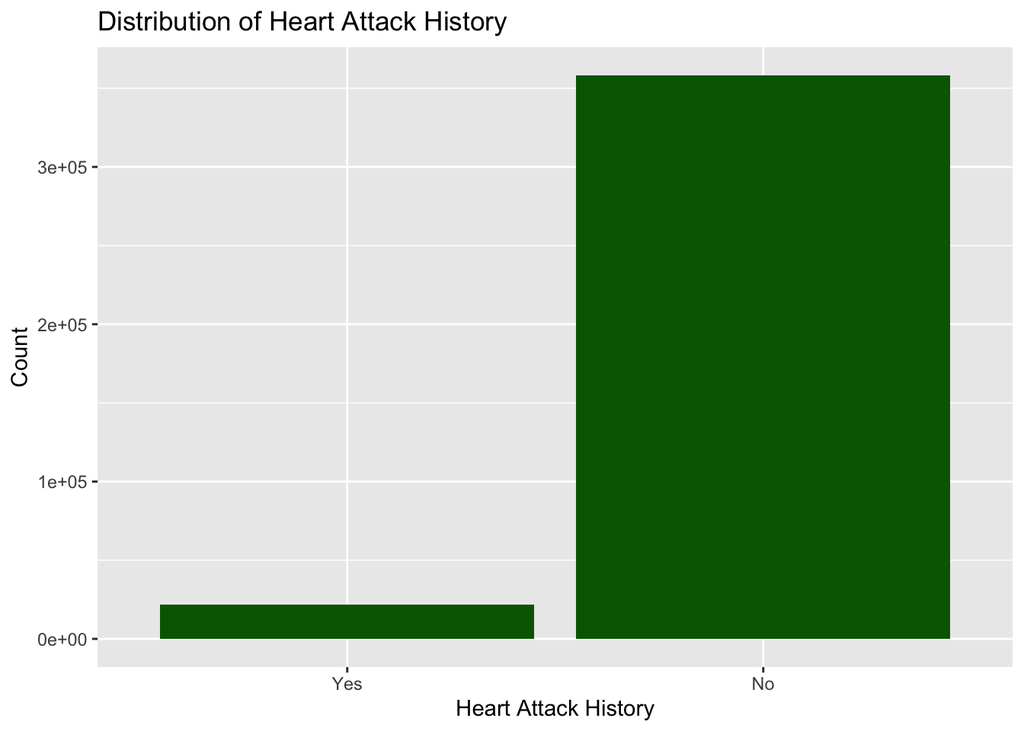

```r
library(ggplot2)

# Heart Attack History
ggplot(Heart_clean, aes(x = Heart_Attack_History)) +
  geom_bar(fill = "darkgreen") +
  labs(title = "Distribution of Heart Attack History",
       x = "Heart Attack History", y = "Count")
```

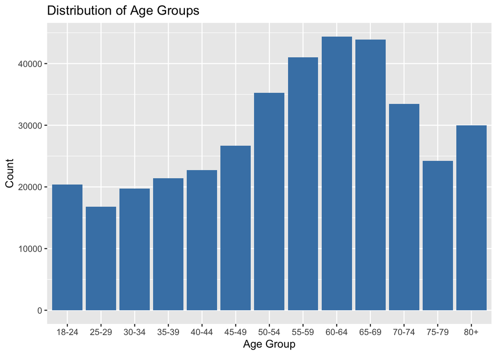

```r
# AGE group
ggplot(Heart_clean, aes(x = Age_Group_5yr)) +
  geom_bar(fill = "steelblue") +
  labs(title = "Distribution of Age Groups",
       x = "Age Group", y = "Count")
```

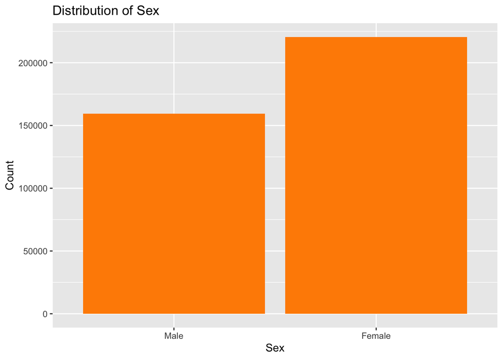

```r
# Sex
ggplot(Heart_clean, aes(x = Sex)) +
  geom_bar(fill = "darkorange") +
  labs(title = "Distribution of Sex",
       x = "Sex", y = "Count")
```

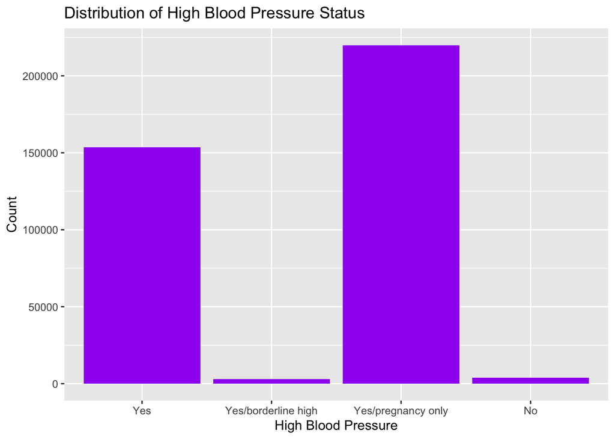

```r
# High blood pressure
ggplot(Heart_clean, aes(x = High_Blood_Pressure)) +
  geom_bar(fill = "purple") +
  labs(title = "Distribution of High Blood Pressure Status",
       x = "High Blood Pressure", y = "Count")
```

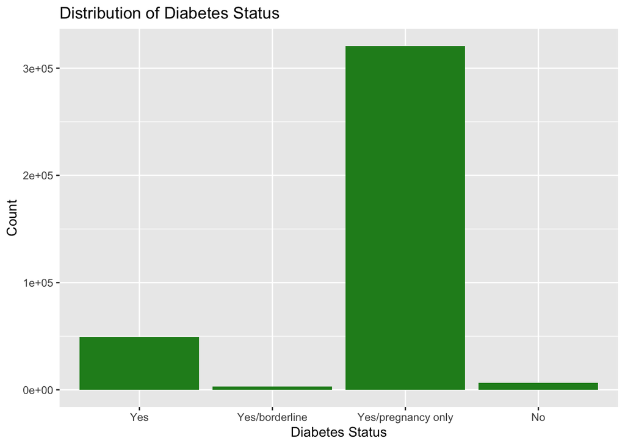

```r
# Diabetes Status
ggplot(Heart_clean, aes(x = Diabetes_Status)) +
  geom_bar(fill = "forestgreen") +
  labs(title = "Distribution of Diabetes Status",
       x = "Diabetes Status", y = "Count")
```

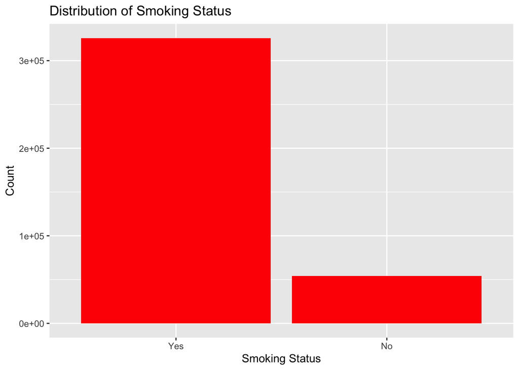

```r
# Smoking Status
ggplot(Heart_clean, aes(x = Smoking_Status)) +
  geom_bar(fill = "red") +
  labs(title = "Distribution of Smoking Status",
       x = "Smoking Status", y = "Count")
```

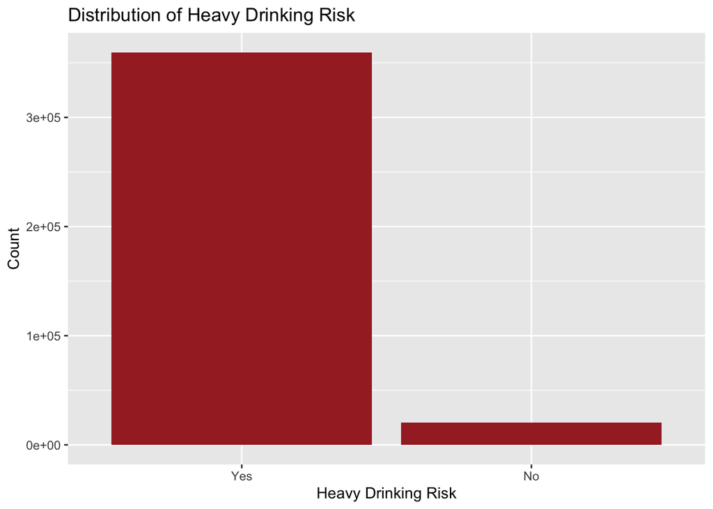

```r
#Heaving Drinking Risk
ggplot(Heart_clean, aes(x = Heavy_Drinking_Risk)) +
  geom_bar(fill = "brown") +
  labs(title = "Distribution of Heavy Drinking Risk",
       x = "Heavy Drinking Risk", y = "Count")
```

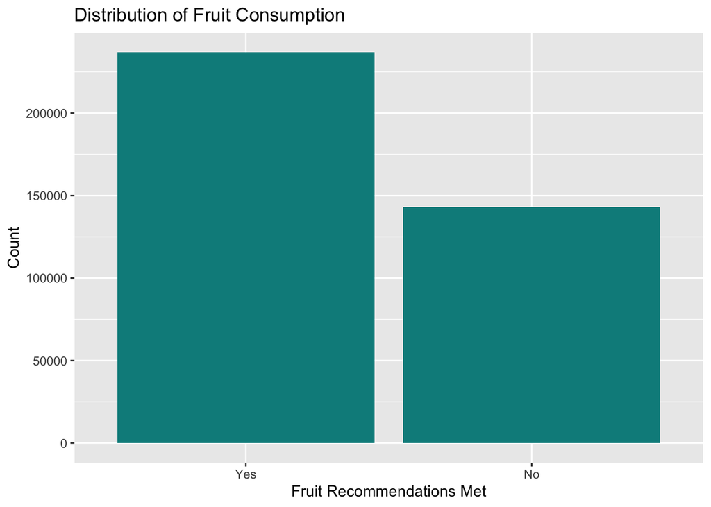

```r
# Fruit_Recommendations_Met
ggplot(Heart_clean, aes(x = Fruit_Recommendations_Met)) +
  geom_bar(fill = "darkcyan") +
  labs(title = "Distribution of Fruit Consumption",
       x = "Fruit Recommendations Met", y = "Count")
```

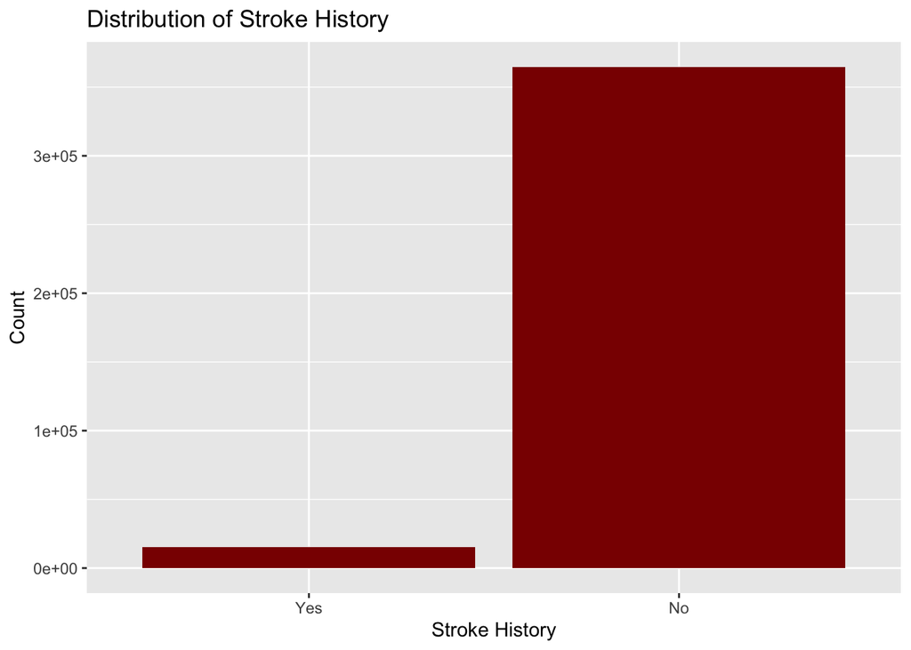

```r
# CVD_Stroke_History
ggplot(Heart_clean, aes(x = CVD_Stroke_History)) +
  geom_bar(fill = "darkred") +
  labs(title = "Distribution of Stroke History",
       x = "Stroke History", y = "Count")
```

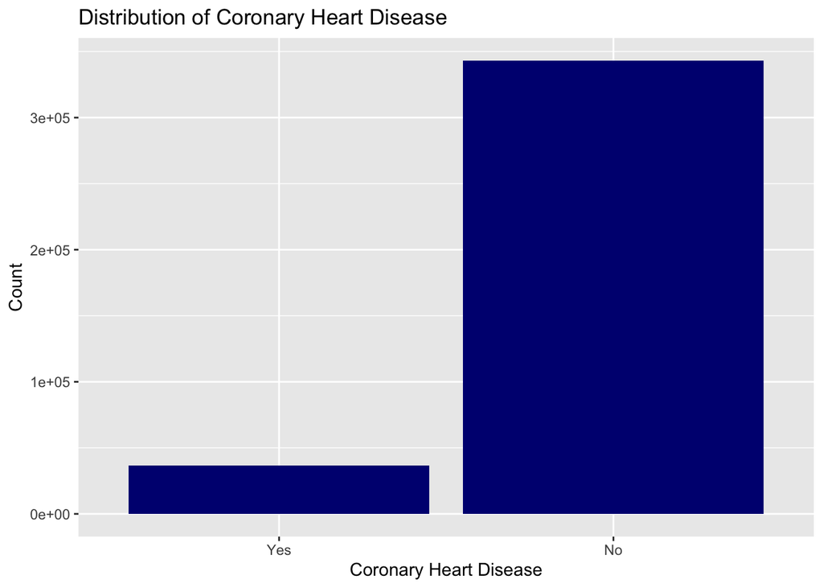

```r
#Coronary_Heart_Disease
ggplot(Heart_clean, aes(x = Coronary_Heart_Disease)) +
  geom_bar(fill = "navy") +
  labs(title = "Distribution of Coronary Heart Disease",
       x = "Coronary Heart Disease", y = "Count")
```

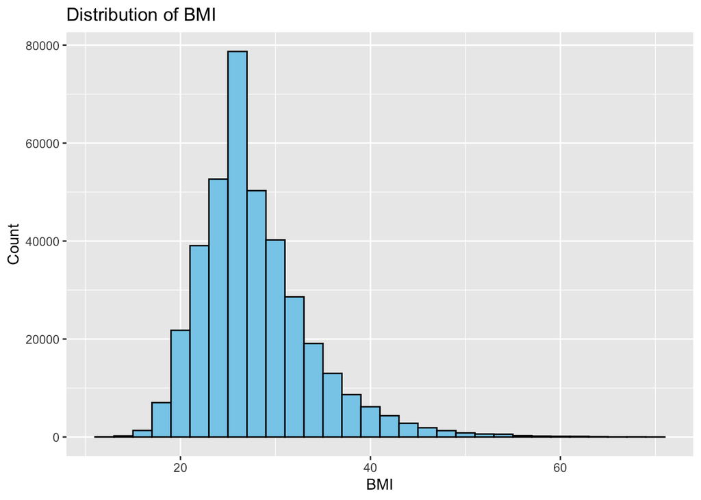

```r
# BMI
ggplot(na.omit(Heart_clean), aes(x = X_BMI5)) +
  geom_histogram(binwidth = 2, fill = "skyblue", color = "black") +
  labs(title = "Distribution of BMI",
       x = "BMI", y = "Count")
```

# Data Analysis

```r
# t-test
# Age group
chisq.test(table(Heart_data$Heart_Attack_History,
                 Heart_data$Age_Group_5yr, useNA = "no"))
```

```
##
##  Pearson's Chi-squared test
##
## data:  table(Heart_data$Heart_Attack_History, Heart_data$Age_Group_5yr,     useNA = "no")
## X-squared = 15227, df = 12, p-value <2e-16
```

```r
# Sex
chisq.test(table(Heart_data$Heart_Attack_History,
                 Heart_data$Sex, useNA = "no"))
```

```
##
##  Pearson's Chi-squared test with Yates' continuity correction
##
## data:  table(Heart_data$Heart_Attack_History, Heart_data$Sex, useNA = "no")
## X-squared = 2344, df = 1, p-value <2e-16
```

```r
# High Blood Pressure
chisq.test(table(Heart_data$Heart_Attack_History,
                 Heart_data$High_Blood_Pressure, useNA = "no"))
```

```
##
##  Pearson's Chi-squared test
##
## data:  table(Heart_data$Heart_Attack_History, Heart_data$High_Blood_Pressure,     useNA = "no")
## X-squared = 12788, df = 3, p-value <2e-16
```

```r
# Diabetes Status
chisq.test(table(Heart_data$Heart_Attack_History,
                 Heart_data$Diabetes_Status, useNA = "no"))
```

```
##
##  Pearson's Chi-squared test
##
## data:  table(Heart_data$Heart_Attack_History, Heart_data$Diabetes_Status,     useNA = "no")
## X-squared = 10493, df = 3, p-value <2e-16
```

```r
# Smoking
chisq.test(table(Heart_data$Heart_Attack_History,
                 Heart_data$Smoking_Status, useNA = "no"))
```

```
##
##  Pearson's Chi-squared test with Yates' continuity correction
##
## data:  table(Heart_data$Heart_Attack_History, Heart_data$Smoking_Status,     useNA = "no")
## X-squared = 450, df = 1, p-value <2e-16
```

```r
# Heavy Drinking Risk
chisq.test(table(Heart_data$Heart_Attack_History,
                 Heart_data$Heavy_Drinking_Risk, useNA = "no"))
```

```
##
##  Pearson's Chi-squared test with Yates' continuity correction
##
## data:  table(Heart_data$Heart_Attack_History, Heart_data$Heavy_Drinking_Risk,     useNA = "no")
## X-squared = 225, df = 1, p-value <2e-16
```

```r
# Fruit Recommendations
chisq.test(table(Heart_data$Heart_Attack_History,
                 Heart_data$Fruit_Recommendations_Met, useNA = "no"))
```

```
##
##  Pearson's Chi-squared test with Yates' continuity correction
##
## data:  table(Heart_data$Heart_Attack_History, Heart_data$Fruit_Recommendations_Met,     useNA = "no")
## X-squared = 96, df = 1, p-value <2e-16
```

```r
# Stroke History
chisq.test(table(Heart_data$Heart_Attack_History,
                 Heart_data$CVD_Stroke_History, useNA = "no"))
```

```
##
##  Pearson's Chi-squared test with Yates' continuity correction
##
## data:  table(Heart_data$Heart_Attack_History, Heart_data$CVD_Stroke_History,     useNA = "no")
## X-squared = 17770, df = 1, p-value <2e-16
```

```r
# Coronary Heart Disease
chisq.test(table(Heart_data$Heart_Attack_History,
                 Heart_data$Coronary_Heart_Disease, useNA = "no"))
```

```
##
##  Pearson's Chi-squared test with Yates' continuity correction
##
## data:  table(Heart_data$Heart_Attack_History, Heart_data$Coronary_Heart_Disease,     useNA = "no")
## X-squared = 1697, df = 1, p-value <2e-16
```

```r
# anova

# BMI
anova_bmi <- aov(X_BMI5 ~ Heart_Attack_History, data = Heart_data, na.action = na.omit)
summary(anova_bmi)
```

```
##                          Df   Sum Sq Mean Sq F value Pr(>F)
## Heart_Attack_History      1    28519   28519     646 <2e-16 ***
## Residuals            403147 17805553      44
## ---
## Signif. codes:  0 '***' 0.001 '**' 0.01 '*' 0.05 '.' 0.1 ' ' 1
## 38307 observations deleted due to missingness
```

Chi- suared test

Age group vs. Heart attack history The chi-squared test shows a very strong relationship between age group and heart attack history (p < 2e-16). This means it is almost impossible that the result happened by chance.

Sex vs. Heart attack history The chi-squared test shows a very strong relationship between sex and heart attack history (p < 2e-16). This means it is almost impossible that the result happened by chance.

High blood pressure vs. Heart attack history The chi-squared test shows a very strong relationship between high blood pressure and heart attack history (p < 2e-16). This means it is almost impossible that the result happened by chance.

Diabetes status vs. Heart attack history The chi-squared test shows a very strong relationship between diabetes status and heart attack history (p < 2e-16). This means it is almost impossible that the result happened by chance.

Smoking status vs. Heart attack history The chi-squared test shows a very strong relationship between smoking status and heart attack history (p < 2e-16). This means it is almost impossible that the result happened by chance.

Heavy drinking risk vs. Heart attack history The chi-squared test shows a very strong relationship between heavy drinking risk and heart attack history (p < 2e-16). This means it is almost impossible that the result happened by chance.

Fruit consumption vs. Heart attack history The chi-squared test shows a very strong relationship between fruit consumption and heart attack history (p < 2e-16). This means it is almost impossible that the result happened by chance.

Stroke history vs. Heart attack history The chi-squared test shows a very strong relationship between stroke history and heart attack history (p < 2e-16). This means it is almost impossible that the result happened by chance.

Coronary heart disease vs. Heart attack history The chi-squared test shows a very strong relationship between coronary heart disease and heart attack history (p < 2e-16). This means it is almost impossible that the result happened by chance.

Anova test

BMI vs. Heart attack history The ANOVA test shows a very strong relationship between BMI and heart attack history (p < 2e-16). This means it is almost impossible that the result happened by chance.